# Data Visualization with R

# Creating a Line Plot

```r
require(dplyr)
require(ggplot2)
```

Line plots are used to display how one continuous variable, on the y-axis, changes in relation to another continuous variable, on the x-axis. It is similar to a scatter plot, except that points are ordered in the x-axis and connected by a segment. Points can also be missing.

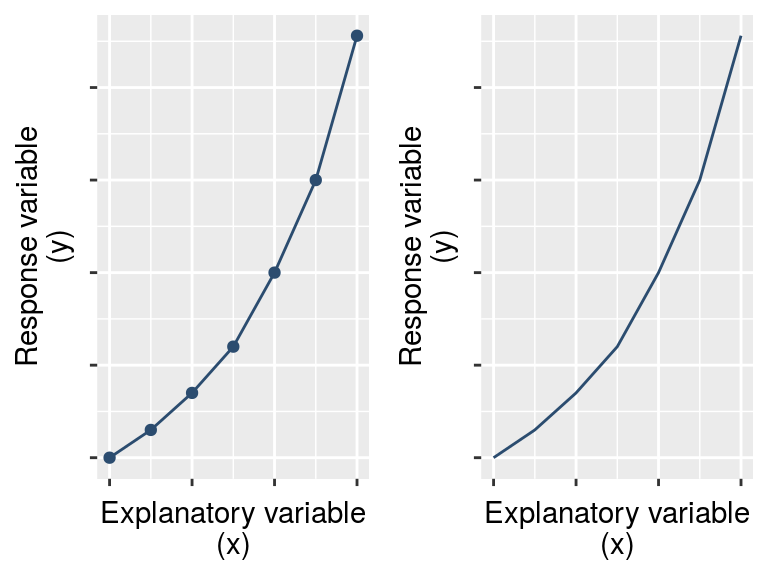

This chapter presents how to build line plots and introduces other basic concepts of `ggplot2` graphics: `group` aesthetic and manual scales.

## The first line plot

`ChickWeight` data contains the body weight of 50 chicks over time. Suppose you are interested to the growth of the first chick.

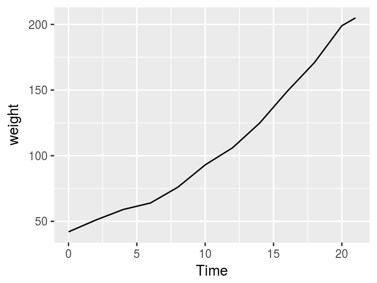

```r
ggplot(data=(ChickWeight %>% filter(Chick==1)), mapping=aes(x=Time, y=weight)) +
  geom_line()
```

You can change the appearance of the line setting `geom_line()` aestethic arguments. For example, you can set dark blue color for line and change the size in this way:

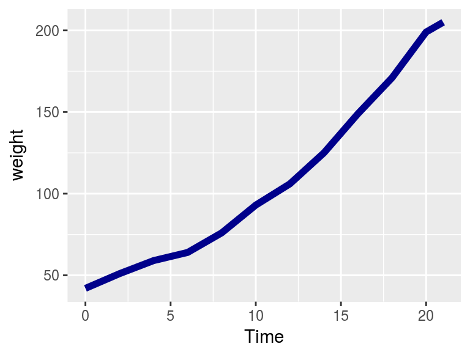

```r
ggplot(data=(ChickWeight %>% filter(Chick==1)), mapping=aes(x=Time, y=weight)) +
  geom_line(colour="darkblue", size = 2)
```

You can also choose the style of the line setting `linetype` argument. If you are experienced with R basic graphic, `linetype` has the same meaning that `lty`.

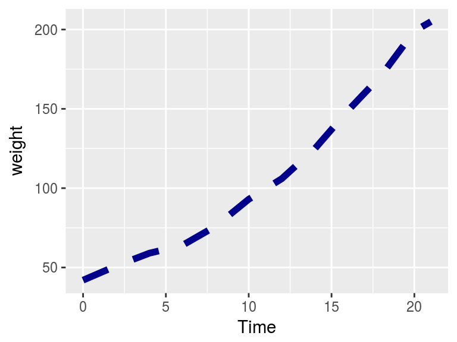

```r
ggplot(data=(ChickWeight %>% filter(Chick==1)), mapping=aes(x=Time, y=weight)) +
  geom_line(colour="darkblue", size = 2, linetype=2)
```

The `linetype` can be a number (0-6) or a description (like `"solid"` or `"dashed"`). Available line types are:

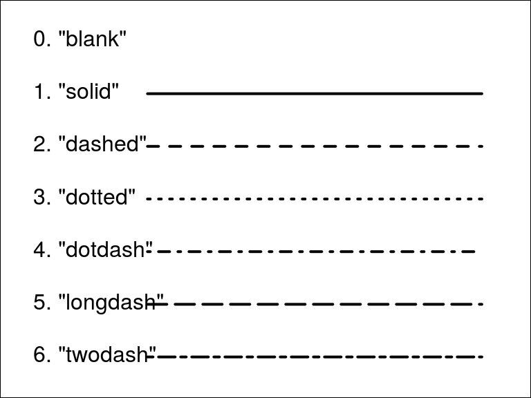

Available aestethics arguments for `geom_line()` are `alpha`, `colour`, `size` and `linetype`. The first three arguments have the same (intuitive) meaning already seen for `geom_point()`.

You can also add points to the plot with `geom_point()`:

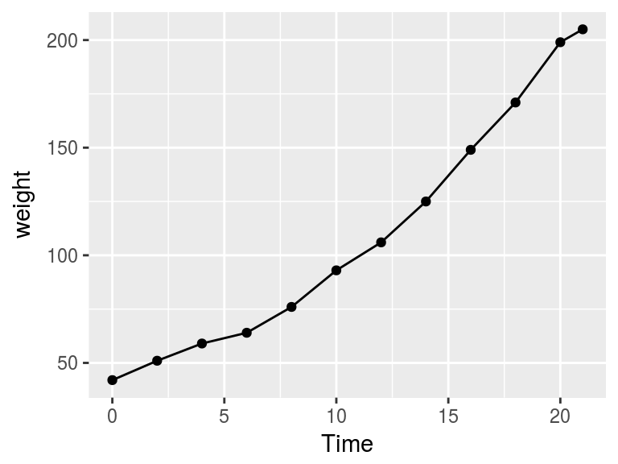

```r
ggplot(data=(ChickWeight %>% filter(Chick==1)), mapping=aes(x=Time, y=weight)) +
  geom_line() +
  geom_point()
```

## Mapping variables to line plots

If you are interested in the average growth of chicks for the different diets, you must first summarize data.

```r
ChickWeightMean <- ChickWeight %>%
  group_by(Time, Diet) %>%
  summarize(weight=mean(weight))
ChickWeightMean
```

```
## # A tibble: 48 x 3
## # Groups:   Time [?]
##     Time   Diet   weight
##    <dbl> <fctr>    <dbl>
##  1     0      1 41.40000
##  2     0      2 40.70000
##  3     0      3 40.80000
##  4     0      4 41.00000
##  5     2      1 47.25000
##  6     2      2 49.40000
##  7     2      3 50.40000
##  8     2      4 51.80000
##  9     4      1 56.47368
## 10     4      2 59.80000
## # ... with 38 more rows
```

If you draw the same plot as above with new data, you will obtain a figure like this one.

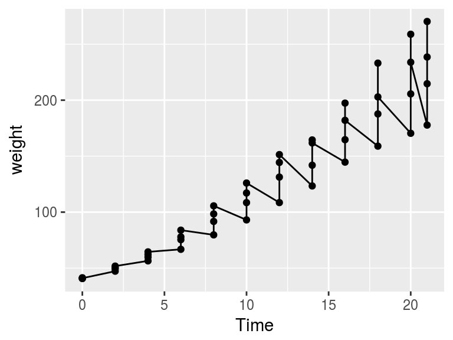

```r
ggplot(data=ChickWeightMean, mapping=aes(x=Time, y=weight)) +
  geom_line() +
  geom_point()
```

A jagged line appears when there are multiple data at each `x` and you tell `ggplot` to connect them. A plot like this one should sounds as a warning that something is wrong. In order to have a single point for each `x` you can summarize your data, or you can draw several lines, accordingly to a third variable, just adding a new aesthetic.

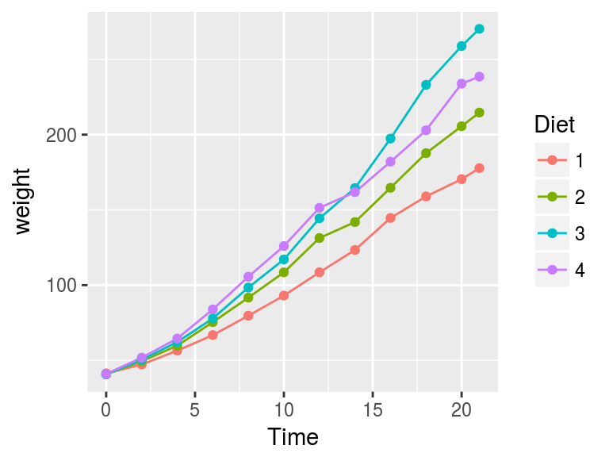

```r
ggplot(data=ChickWeightMean, mapping=aes(x=Time, y=weight, colour=Diet)) +
  geom_line() +
  geom_point()
```

Sometimes, the `x` variable can be a categorical variable. This is the case when you have numerical values that are conceived as categorical ones. The `ToothGrowth` data set can be a good case in point. It provides the effect of Vitamin C on Tooth Growth in Guinea Pigs. Data can be summarized as follow to achieve the mean tooth length by supplier and dose:

```r
tg <- ToothGrowth %>%
  group_by(supp, dose) %>%
  summarize(length=mean(len))
tg
```

```
## # A tibble: 6 x 3
## # Groups:   supp [?]
##     supp  dose length
##   <fctr> <dbl>  <dbl>
## 1     OJ   0.5  13.23
## 2     OJ   1.0  22.70
## 3     OJ   2.0  26.06
## 4     VC   0.5   7.98
## 5     VC   1.0  16.77
## 6     VC   2.0  26.14
```

You can plot a line for each `supp` value:

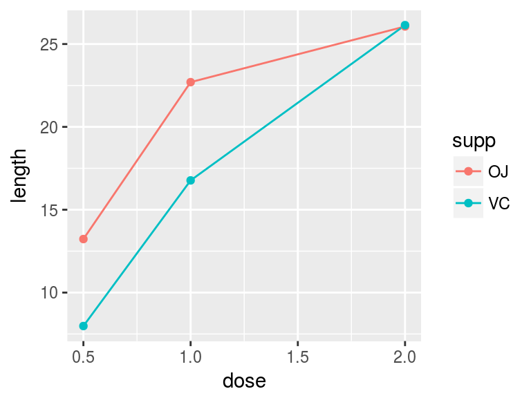

```r
ggplot(data=tg, mapping=aes(x=dose, y=length, colour=supp)) +
  geom_line() +
  geom_point()
```

The plot is good but since `dose` level are fixed the space between 0.5-1.0 and 1.0-2.0 should be the same. You can fix this issue, transforming `dose` into a factor.

```
## geom_path: Each group consists of only one observation. Do you need to adjust the group aesthetic?
```

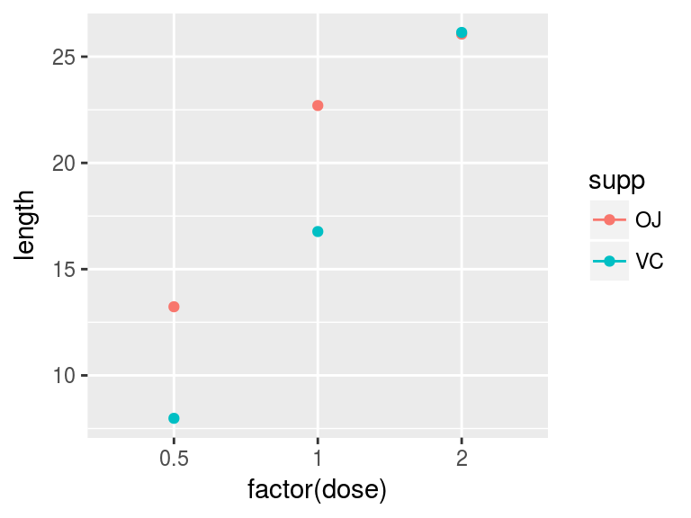

```r
ggplot(data=tg, mapping=aes(x=factor(dose), y=length, colour=supp)) +
  geom_line() +
  geom_point()
```

As you can see from the plot no lines are drawn and a warning message is returned. Probably, this is one of the most frequently problems with `geom_line()`. This appens because `geom_line()` tries to connect data points that belong to same group and the combinations of different levels of factor variables belong to different groups.

To resolve this problem, you have to manually specify the grouping, setting `group` argument:

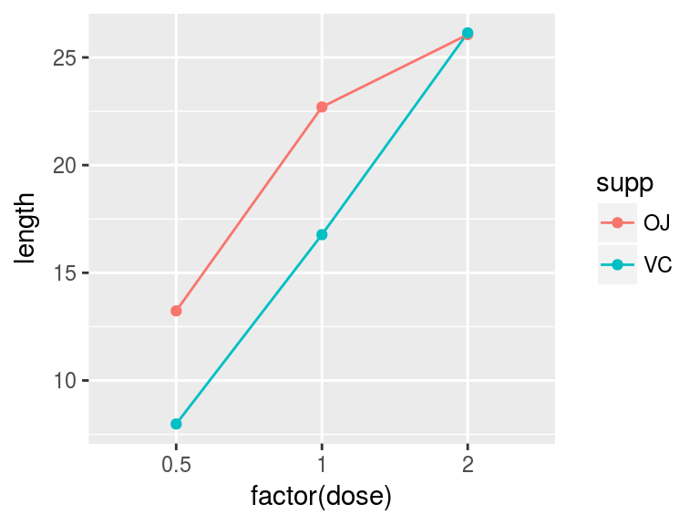

```r
ggplot(data=tg, mapping=aes(x=factor(dose), y=length, colour=supp, group=supp)) +
  geom_line() +
  geom_point()
```

`group=supp` in `aes()` tells ggplot how to group data when it draws the lines.

Otherwise, if you want a single line than connects all data points, you have to specify `group=1`.

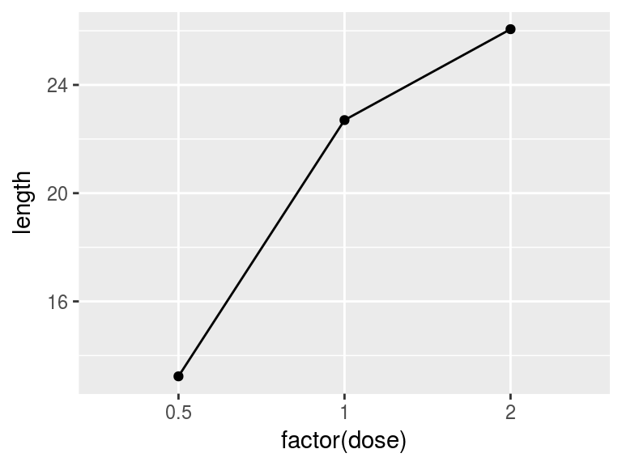

```r
# Consider only "OJ" supplier
ggplot(data=(tg%>%filter(supp=="OJ")), mapping=aes(x=factor(dose), y=length, group=1)) +
  geom_line() +
  geom_point()
```

When points overlap, you can *dodge* them. Dodging adjusts points left and right and must be applied to both lines and points, to avoid misalignment.

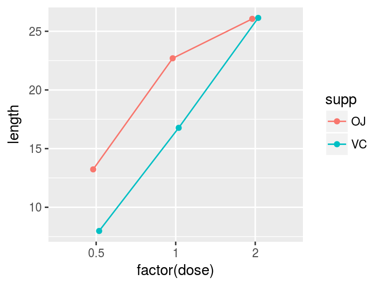

```r
ggplot(data=tg, mapping=aes(x=factor(dose), y=length, colour=supp, group=supp)) +
  geom_line(position=position_dodge(0.15)) +
  geom_point(position=position_dodge(0.15))
```

`position` argument of both `geom_line()` and `geom_point()` is set equal to `position_dodge()`. `position_dodge()` is a `ggplot2` function that adjust position by dodging overlaps to the side. 0.15 is the `width` specified.

## Changing the Appearance of Mapped Aesthetics

When you feed your chicks, you use the “A” fodder for diet 1, the “B” fodder for diet 2, the “C” for diet 3 and the “D” for diet 4.

```r
ChickWeightMean <- ChickWeightMean %>%
  mutate(Diet = factor(Diet, levels=1:4, labels=c("A","B","C","D")))
```

“A” fodder is sold in red bags and farmers immediately identify this product with the red colour. In the same way, B is associated with the blue, C with the green and D with the orange. To improve the readability of the plot, lines for each diet should be of the colour that identify the fodder maker.

You cannot set the colour inside `ggplot()` or `geom_line()` using the `colour` argument, because this is admitted only when a variable is not *mapped* to the `colour` aesthetic. You can set manually the colour with the function `scale_colour_manual()`.

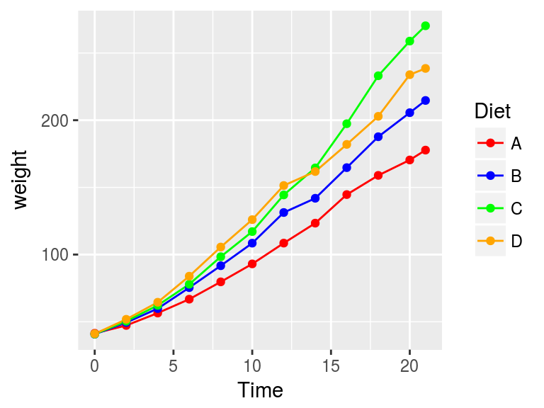

```r
ggplot(data=ChickWeightMean, mapping=aes(x=Time, y=weight, colour=Diet)) +
  geom_line() +
  geom_point() +
  scale_color_manual(values=c("red", "blue", "green", "orange"))
```

Colours in the `values` string vector must appear in the same order as they appear in the legend. You can pass a named vector to be sure of the correspondence between colour and data.

Mapped Aesthetics customization will be deepen in “Mapped Aesthetics Customization” chapter.

## Adding horizontal and vertical lines

Line plots often contains horizontal or vertical lines.

It may be interesting to analyse the average daily growth for each diet type.

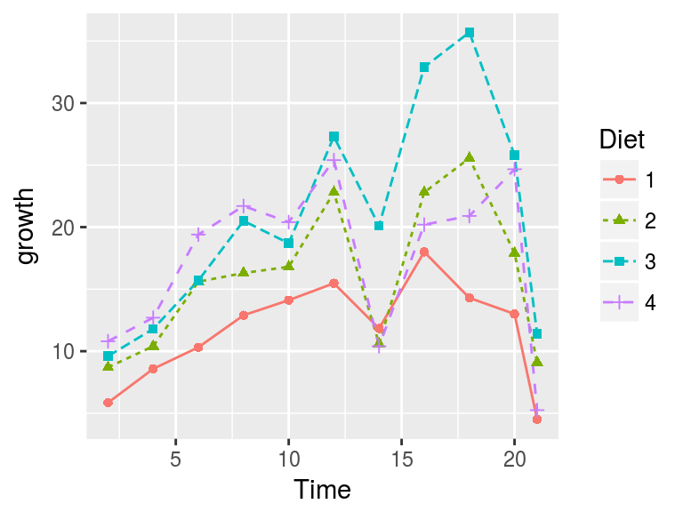

```r
ChickWeightGrowth <- ChickWeight %>%
  group_by(Chick) %>%
  mutate(growth=c(0,diff(weight))) %>%
  filter(growth != 0)

ChickWeightGrowthMean <- ChickWeightGrowth %>%
  group_by(Time, Diet) %>%
  summarize(growth=mean(growth))

ggp <- ggplot(data=ChickWeightGrowthMean, mapping=aes(x=Time, y=growth, colour=Diet)) +
  geom_line(mapping=aes(linetype=Diet)) +
  geom_point(mapping=aes(shape=Diet))

ggp
```

At this point you may want to add the average growth to the plot.

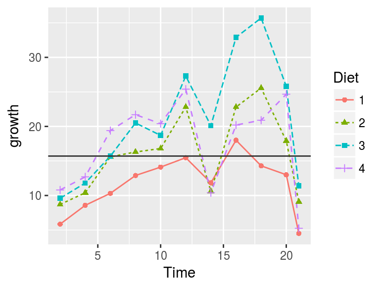

```r
growth_avg <- ChickWeightGrowth %>%
  magrittr::use_series(growth) %>%
  mean

ggp1 <- ggp +
  geom_hline(yintercept = growth_avg, colour="grey20")

ggp1
```

Data refers to a three-weeks period. It may be interesting to highlight each week adding a vertical line at days 7, 14 and 21.

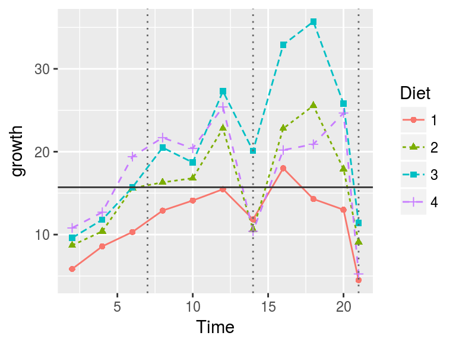

```r
ggp1 +
  geom_vline(xintercept = c(7,14,21), colour="grey40", linetype=3)
```